# Multi-Class Deep Learning Model for Crop Mapping in Canada Using TensorFlow Take 3

### July 21, 2020

Template Credit: Adapted from a template made available by Dr. Jason Brownlee of Machine Learning Mastery. [https://machinelearningmastery.com/]

SUMMARY: The purpose of this project is to construct a predictive model using various machine learning algorithms and to document the end-to-end steps using a template. The Crop Mapping in Canada dataset is a multi-class classification situation where we are trying to predict one of several (more than two) possible outcomes.

INTRODUCTION: This data set is a fused bi-temporal optical-radar data for cropland classification. The organization collected the images using RapidEye satellites (optical) and the Unmanned Aerial Vehicle Synthetic Aperture Radar (UAVSAR) system (Radar) over an agricultural region near Winnipeg, Manitoba, Canada in 2012. There are 2 x 49 radar features and 2 x 38 optical elements for two dates: 05 and 14 July 2012. Seven crop type classes exist for this data set as follows: 1-Corn; 2-Peas; 3-Canola; 4-Soybeans; 5-Oats; 6-Wheat; and 7-Broadleaf.

In the previous Scikit-Learn iterations, we constructed and tuned machine learning models for this dataset using the Scikit-Learn and the XGboost libraries. We also observed the best accuracy result that we could obtain using the tuned models with the training, validation, and test datasets.

In iteration Take1, we constructed and tuned machine learning models for this dataset using TensorFlow with three layers. We also observed the best accuracy result that we could obtain using the tuned models with the validation and test datasets.

In iteration Take2, we constructed and tuned machine learning models for this dataset using TensorFlow with four layers. We also observed the best accuracy result that we could obtain using the tuned models with the validation and test datasets.

In this Take3 iteration, we will construct and tune machine learning models for this dataset using TensorFlow with five layers. We will observe the best accuracy result that we can obtain using the tuned models with the validation and test datasets.

ANALYSIS: From the previous Scikit-Learn iterations, the optimized Extra Trees model processed the testing dataset with an accuracy of 99.74%. The optimized XGBoost model processed the testing dataset with an accuracy of 99.84%.

From iteration Take1, the performance of the three-layer TensorFlow model achieved an accuracy score of 99.82% with the training dataset. After a series of tuning trials, the TensorFlow model processed the validation dataset with an accuracy score of 99.83%, which was consistent with the prediction from the training result. When configured with the optimized parameters, the TensorFlow model processed the test dataset with an accuracy score of 99.84%, which was consistent with the prediction results from the training and validation phases.

From iteration Take2, the performance of the four-layer TensorFlow model achieved an accuracy score of 99.72% with the training dataset. After a series of tuning trials, the TensorFlow model processed the validation dataset with an accuracy score of 99.82%, which was consistent with the prediction from the training result. When configured with the optimized parameters, the TensorFlow model processed the test dataset with an accuracy score of 99.85%, which was consistent with the prediction results from the training and validation phases.

CONCLUSION: For this dataset, the five-layer TensorFlow model achieved a satisfactory result, and we should consider using it for future modeling activities.

Dataset Used: Crop Mapping in Canada Data Set

Dataset ML Model: Multi-Class classification with numerical attributes

Dataset Reference: https://archive.ics.uci.edu/ml/datasets/Crop+mapping+using+fused+optical-radar+data+set

A deep-learning modeling project generally can be broken down into five major tasks:

1. Prepare Environment
2. Load and Prepare Data
3. Define and Train Model
4. Evaluate and Optimize Model
5. Finalize Model and Make Predictions

# Task 1. Prepare Environment

```python
# Install the packages to support accessing environment variable and SQL databases
!pip install python-dotenv PyMySQL
```

```
     |████████████████████████████████| 51kB 5.0MB/s
```

```python
# Retrieve GPU configuration information from Colab
gpu_info = !nvidia-smi
gpu_info = '\n'.join(gpu_info)
if gpu_info.find('failed') >= 0:
    print('Select the Runtime → "Change runtime type" menu to enable a GPU accelerator, ')
    print('and then re-execute this cell.')
else:
    print(gpu_info)
```

```
Fri Jul 17 13:54:00 2020
+-----------------------------------------------------------------------------+
| NVIDIA-SMI 450.51.05    Driver Version: 418.67       CUDA Version: 10.1     |
|-------------------------------+----------------------+----------------------+
| GPU  Name        Persistence-M| Bus-Id        Disp.A | Volatile Uncorr. ECC |
| Fan  Temp  Perf  Pwr:Usage/Cap|         Memory-Usage | GPU-Util  Compute M. |
|                               |                      |               MIG M. |
|===============================+======================+======================|
|   0  Tesla P100-PCIE...  Off  | 00000000:00:04.0 Off |                    0 |
| N/A   34C    P0    26W / 250W |      0MiB / 16280MiB |      0%      Default |
|                               |                      |                 ERR! |
+-------------------------------+----------------------+----------------------+

+-----------------------------------------------------------------------------+
| Processes:                                                                  |
|  GPU   GI   CI        PID   Type   Process name                  GPU Memory |
|        ID   ID                                                   Usage      |
|=============================================================================|
|  No running processes found                                                 |
+-----------------------------------------------------------------------------+
```

```python
# Retrieve memory configuration information from Colab
from psutil import virtual_memory
ram_gb = virtual_memory().total / 1e9
print('Your runtime has {:.1f} gigabytes of available RAM\n'.format(ram_gb))

if ram_gb < 20:
    print('To enable a high-RAM runtime, select the Runtime → "Change runtime type"')
    print('menu, and then select High-RAM in the Runtime shape dropdown. Then, ')
    print('re-execute this cell.')
else:
    print('You are using a high-RAM runtime!')
```

```
Your runtime has 13.7 gigabytes of available RAM

To enable a high-RAM runtime, select the Runtime → "Change runtime type"
menu, and then select High-RAM in the Runtime shape dropdown. Then,
re-execute this cell.
```

```python
# Retrieve CPU information from the system
ncpu = !nproc
print("The number of available CPUs is:", ncpu[0])
```

```
The number of available CPUs is: 2
```

```python
# Direct Colab to use TensorFlow v2
%tensorflow_version 2.x
```

```python
# Set the random seed number for reproducible results
seedNum = 888
```

```python
# Load libraries and packages
import random
random.seed(seedNum)
import numpy as np
np.random.seed(seedNum)
import tensorflow as tf
tf.random.set_seed(seedNum)
from tensorflow.keras import Sequential
from tensorflow.keras.layers import Dense
from tensorflow.keras.layers import Flatten
from tensorflow.keras.layers import Dropout
from tensorflow.keras.layers import Conv2D
from tensorflow.keras.layers import MaxPooling2D
from tensorflow.keras.layers import BatchNormalization
import pandas as pd
import matplotlib.pyplot as plt
import os
import sys
import math
import boto3
from datetime import datetime
from dotenv import load_dotenv
from sklearn import preprocessing
from sklearn.model_selection import train_test_split
```

```python
# Begin the timer for the script processing
startTimeScript = datetime.now()

# Check the number of GPUs accessible through TensorFlow
print("Num GPUs Available: ", len(tf.config.experimental.list_physical_devices('GPU')))

# Set up the number of CPU cores available for multi-thread processing
n_jobs = 1

# Set up the flag to stop sending progress emails (setting to True will send status emails!)
notifyStatus = False

# Set up the parent directory location for loading the dotenv files
useGDrive = False
if useGDrive:
    # Mount Google Drive locally for storing files
    from google.colab import drive
    drive.mount('/content/gdrive')
    gdrivePrefix = '/content/gdrive/My Drive/Colab_Downloads/'
    env_path = '/content/gdrive/My Drive/Colab Notebooks/'
    dotenv_path = env_path + "python_script.env"
    load_dotenv(dotenv_path=dotenv_path)

# Set up the dotenv file for retrieving environment variables
useLocalPC = False
if useLocalPC:
    env_path = "/Users/david/PycharmProjects/"
    dotenv_path = env_path + "python_script.env"
    load_dotenv(dotenv_path=dotenv_path)

# Configure the plotting style
plt.style.use('seaborn')

# Set Pandas options
pd.set_option("display.max_rows", 500)
pd.set_option("display.width", 140)

# Set the percentage sizes for splitting the dataset
test_set_size = 0.2
val_set_size = 0.25

# Set the number of folds for cross validation
n_folds = 5

# Set various default Keras modeling parameters
default_loss = 'categorical_crossentropy'
default_metrics = ['accuracy']
default_optimizer = tf.keras.optimizers.Adam(learning_rate=0.001)
default_kernel_init = tf.keras.initializers.he_uniform(seed=seedNum)
default_epoch = 30
default_batch = 64
num_class = 7

# Define the labels to use for graphing the data
train_metric = "accuracy"
validation_metric = "val_accuracy"
train_loss = "loss"
validation_loss = "val_loss"
```

```
Num GPUs Available:  1
```

```python
# Set up the email notification function
def status_notify(msg_text):
    access_key = os.environ.get('SNS_ACCESS_KEY')
    secret_key = os.environ.get('SNS_SECRET_KEY')
    aws_region = os.environ.get('SNS_AWS_REGION')
    topic_arn = os.environ.get('SNS_TOPIC_ARN')
    if (access_key is None) or (secret_key is None) or (aws_region is None) or (topic_arn is None):
        sys.exit("Incomplete notification setup info. Script Processing Aborted!!!")
    sns = boto3.client('sns', aws_access_key_id=access_key, aws_secret_access_key=secret_key, region_name=aws_region)
    response = sns.publish(TopicArn=topic_arn, Message=msg_text)
    if response['ResponseMetadata']['HTTPStatusCode'] != 200 :
        print('Status notification not OK with HTTP status code:', response['ResponseMetadata']['HTTPStatusCode'])
```

```python
# Reset the random number generators
def reset_random(x):
    random.seed(x)
    np.random.seed(x)
    tf.random.set_seed(x)
```

```python
if (notifyStatus): status_notify("Task 1. Prepare Environment completed! "+datetime.now().strftime('%a %B %d, %Y %I:%M:%S %p'))
```

# Task 2. Load and Prepare Data

```python
if (notifyStatus): status_notify("Task 2. Load and Prepare Data has begun! "+datetime.now().strftime('%a %B %d, %Y %I:%M:%S %p'))
```

## 2.a) Load Dataset

```python
dataset_path = 'https://dainesanalytics.com/datasets/crop-mapping-winnipeg/WinnipegDataset.txt'
Xy_original = pd.read_csv(dataset_path)

# Take a peek at the dataframe after the import
Xy_original.head(10)
```

|  | label | f1 | f2 | f3 | f4 | f5 | f6 | f7 | f8 | f9 | f10 | f11 | f12 | f13 | f14 | f15 | f16 | f17 | f18 | f19 | f20 | f21 | f22 | f23 | f24 | f25 | f26 | f27 | f28 | … |
| --- | --- | --- | --- | --- | --- | --- | --- | --- | --- | --- | --- | --- | --- | --- | --- | --- | --- | --- | --- | --- | --- | --- | --- | --- | --- | --- | --- | --- | --- | --- |
| 0 | 1 | -13.559 | -21.407 | -11.4040 | -15.248 | -11.923 | -15.291 | -2.1548 | -7.8474 | -10.0020 | 0.04239 | 3.3253 | 3.3677 | 0.35631 | 0.058490 | 0.58520 | 0.24150 | 0.51934 | 0.23916 | -0.62424 | -0.81493 | -0.70844 | -0.65641 | -0.19568 | -0.63160 | 0.091945 | 0.026703 | 0.005017 | 0.62019 | … |
| 1 | 1 | -12.802 | -20.335 | -10.3990 | -14.132 | -11.096 | -14.361 | -2.4039 | -7.5330 | -9.9369 | 0.22842 | 3.0360 | 3.2644 | 0.34295 | 0.060525 | 0.59652 | 0.25249 | 0.50796 | 0.23955 | -0.57229 | -0.74854 | -0.64839 | -0.62810 | -0.18825 | -0.55448 | 0.115710 | 0.031183 | 0.006051 | 0.60356 | … |
| 2 | 1 | -12.431 | -19.902 | -10.0740 | -13.598 | -10.829 | -14.048 | -2.3566 | -7.4717 | -9.8283 | 0.44978 | 2.7687 | 3.2185 | 0.34489 | 0.061731 | 0.59338 | 0.26362 | 0.49870 | 0.23768 | -0.53347 | -0.70253 | -0.58846 | -0.61836 | -0.17804 | -0.48642 | 0.127130 | 0.032382 | 0.006162 | 0.58683 | … |
| 3 | 1 | -12.689 | -19.529 | -10.0280 | -13.350 | -11.056 | -14.014 | -2.6611 | -6.8396 | -9.5006 | 0.66378 | 2.2942 | 2.9580 | 0.32760 | 0.067825 | 0.60457 | 0.28135 | 0.47717 | 0.24148 | -0.50405 | -0.66998 | -0.52543 | -0.61169 | -0.17507 | -0.43576 | 0.127200 | 0.031091 | 0.006040 | 0.57769 | … |
| 4 | 1 | -12.686 | -19.278 | -9.8185 | -13.108 | -10.932 | -13.939 | -2.8675 | -6.5919 | -9.4594 | 0.83143 | 2.1756 | 3.0070 | 0.31701 | 0.069483 | 0.61351 | 0.28768 | 0.47476 | 0.23756 | -0.50314 | -0.68221 | -0.50731 | -0.59134 | -0.17505 | -0.45195 | 0.131550 | 0.031960 | 0.006439 | 0.57937 | … |
| 5 | 1 | -12.478 | -19.034 | -9.6201 | -12.888 | -10.761 | -13.687 | -2.8583 | -6.5555 | -9.4138 | 0.79854 | 2.1276 | 2.9261 | 0.31723 | 0.070118 | 0.61265 | 0.28867 | 0.47115 | 0.24018 | -0.49984 | -0.69457 | -0.50160 | -0.58093 | -0.17393 | -0.45870 | 0.138010 | 0.033254 | 0.006886 | 0.57967 | … |
| 6 | 1 | -12.459 | -19.019 | -9.3854 | -12.766 | -10.664 | -13.393 | -3.0739 | -6.5599 | -9.6338 | 0.62733 | 2.1023 | 2.7297 | 0.30766 | 0.067934 | 0.62440 | 0.28668 | 0.46519 | 0.24812 | -0.45483 | -0.64691 | -0.47553 | -0.51887 | -0.15984 | -0.42968 | 0.145800 | 0.031903 | 0.006798 | 0.55627 | … |
| 7 | 1 | -12.721 | -19.057 | -9.4054 | -12.887 | -10.797 | -13.384 | -3.3153 | -6.3366 | -9.6519 | 0.49645 | 2.0904 | 2.5868 | 0.29604 | 0.068815 | 0.63515 | 0.28488 | 0.46100 | 0.25411 | -0.42858 | -0.60544 | -0.45454 | -0.48445 | -0.15522 | -0.41000 | 0.144320 | 0.029664 | 0.006563 | 0.54273 | … |
| 8 | 1 | -12.777 | -19.202 | -9.2785 | -12.905 | -10.762 | -13.213 | -3.4982 | -6.4252 | -9.9234 | 0.30780 | 2.1437 | 2.4515 | 0.28855 | 0.065722 | 0.64572 | 0.28013 | 0.45891 | 0.26096 | -0.39564 | -0.58572 | -0.44087 | -0.44121 | -0.14412 | -0.38875 | 0.148360 | 0.028158 | 0.006335 | 0.52267 | … |
| 9 | 1 | -12.804 | -19.273 | -9.2722 | -12.937 | -10.802 | -13.143 | -3.5322 | -6.4682 | -10.0000 | 0.20590 | 2.1353 | 2.3412 | 0.28728 | 0.064787 | 0.64793 | 0.27865 | 0.45561 | 0.26575 | -0.37654 | -0.55633 | -0.43470 | -0.42874 | -0.13967 | -0.36161 | 0.149380 | 0.027014 | 0.006100 | 0.50998 | … |

10 rows × 175 columns

```python
Xy_original.info(verbose=True)
```

```
<class 'pandas.core.frame.DataFrame'>
RangeIndex: 325834 entries, 0 to 325833
Data columns (total 175 columns):
 #   Column  Dtype
---  ------  -----
 0   label   int64
 1   f1      float64
 2   f2      float64
 3   f3      float64
 4   f4      float64
 5   f5      float64
 6   f6      float64
 7   f7      float64
 8   f8      float64
 9   f9      float64
```

[output cut: 167 more lines]

```python
null_counts = Xy_original.isnull().sum()
null_counts[null_counts > 0]
```

```
Series([], dtype: int64)
```

```python
print('Total number of NaN in the dataframe: ', Xy_original.isnull().sum().sum())
```

```
Total number of NaN in the dataframe:  0
```

## 2.b) Data Cleaning

```python
# Standardize the class column to the name of targetVar if required
Xy_original = Xy_original.rename(columns={'label': 'targetVar'})

# Convert columns from one data type to another
Xy_original['f137'] = Xy_original['f137'].astype('float')
Xy_original['f138'] = Xy_original['f138'].astype('float')
Xy_original['f139'] = Xy_original['f139'].astype('float')
Xy_original['f140'] = Xy_original['f140'].astype('float')
Xy_original['f141'] = Xy_original['f141'].astype('float')

# Take a peek at the dataframe after cleaning
Xy_original.head(10)
```

|  | targetVar | f1 | f2 | f3 | f4 | f5 | f6 | f7 | f8 | f9 | f10 | f11 | f12 | f13 | f14 | f15 | f16 | f17 | f18 | f19 | f20 | f21 | f22 | f23 | f24 | f25 | f26 | f27 | f28 | … |
| --- | --- | --- | --- | --- | --- | --- | --- | --- | --- | --- | --- | --- | --- | --- | --- | --- | --- | --- | --- | --- | --- | --- | --- | --- | --- | --- | --- | --- | --- | --- |
| 0 | 1 | -13.559 | -21.407 | -11.4040 | -15.248 | -11.923 | -15.291 | -2.1548 | -7.8474 | -10.0020 | 0.04239 | 3.3253 | 3.3677 | 0.35631 | 0.058490 | 0.58520 | 0.24150 | 0.51934 | 0.23916 | -0.62424 | -0.81493 | -0.70844 | -0.65641 | -0.19568 | -0.63160 | 0.091945 | 0.026703 | 0.005017 | 0.62019 | … |
| 1 | 1 | -12.802 | -20.335 | -10.3990 | -14.132 | -11.096 | -14.361 | -2.4039 | -7.5330 | -9.9369 | 0.22842 | 3.0360 | 3.2644 | 0.34295 | 0.060525 | 0.59652 | 0.25249 | 0.50796 | 0.23955 | -0.57229 | -0.74854 | -0.64839 | -0.62810 | -0.18825 | -0.55448 | 0.115710 | 0.031183 | 0.006051 | 0.60356 | … |
| 2 | 1 | -12.431 | -19.902 | -10.0740 | -13.598 | -10.829 | -14.048 | -2.3566 | -7.4717 | -9.8283 | 0.44978 | 2.7687 | 3.2185 | 0.34489 | 0.061731 | 0.59338 | 0.26362 | 0.49870 | 0.23768 | -0.53347 | -0.70253 | -0.58846 | -0.61836 | -0.17804 | -0.48642 | 0.127130 | 0.032382 | 0.006162 | 0.58683 | … |
| 3 | 1 | -12.689 | -19.529 | -10.0280 | -13.350 | -11.056 | -14.014 | -2.6611 | -6.8396 | -9.5006 | 0.66378 | 2.2942 | 2.9580 | 0.32760 | 0.067825 | 0.60457 | 0.28135 | 0.47717 | 0.24148 | -0.50405 | -0.66998 | -0.52543 | -0.61169 | -0.17507 | -0.43576 | 0.127200 | 0.031091 | 0.006040 | 0.57769 | … |
| 4 | 1 | -12.686 | -19.278 | -9.8185 | -13.108 | -10.932 | -13.939 | -2.8675 | -6.5919 | -9.4594 | 0.83143 | 2.1756 | 3.0070 | 0.31701 | 0.069483 | 0.61351 | 0.28768 | 0.47476 | 0.23756 | -0.50314 | -0.68221 | -0.50731 | -0.59134 | -0.17505 | -0.45195 | 0.131550 | 0.031960 | 0.006439 | 0.57937 | … |
| 5 | 1 | -12.478 | -19.034 | -9.6201 | -12.888 | -10.761 | -13.687 | -2.8583 | -6.5555 | -9.4138 | 0.79854 | 2.1276 | 2.9261 | 0.31723 | 0.070118 | 0.61265 | 0.28867 | 0.47115 | 0.24018 | -0.49984 | -0.69457 | -0.50160 | -0.58093 | -0.17393 | -0.45870 | 0.138010 | 0.033254 | 0.006886 | 0.57967 | … |
| 6 | 1 | -12.459 | -19.019 | -9.3854 | -12.766 | -10.664 | -13.393 | -3.0739 | -6.5599 | -9.6338 | 0.62733 | 2.1023 | 2.7297 | 0.30766 | 0.067934 | 0.62440 | 0.28668 | 0.46519 | 0.24812 | -0.45483 | -0.64691 | -0.47553 | -0.51887 | -0.15984 | -0.42968 | 0.145800 | 0.031903 | 0.006798 | 0.55627 | … |
| 7 | 1 | -12.721 | -19.057 | -9.4054 | -12.887 | -10.797 | -13.384 | -3.3153 | -6.3366 | -9.6519 | 0.49645 | 2.0904 | 2.5868 | 0.29604 | 0.068815 | 0.63515 | 0.28488 | 0.46100 | 0.25411 | -0.42858 | -0.60544 | -0.45454 | -0.48445 | -0.15522 | -0.41000 | 0.144320 | 0.029664 | 0.006563 | 0.54273 | … |
| 8 | 1 | -12.777 | -19.202 | -9.2785 | -12.905 | -10.762 | -13.213 | -3.4982 | -6.4252 | -9.9234 | 0.30780 | 2.1437 | 2.4515 | 0.28855 | 0.065722 | 0.64572 | 0.28013 | 0.45891 | 0.26096 | -0.39564 | -0.58572 | -0.44087 | -0.44121 | -0.14412 | -0.38875 | 0.148360 | 0.028158 | 0.006335 | 0.52267 | … |
| 9 | 1 | -12.804 | -19.273 | -9.2722 | -12.937 | -10.802 | -13.143 | -3.5322 | -6.4682 | -10.0000 | 0.20590 | 2.1353 | 2.3412 | 0.28728 | 0.064787 | 0.64793 | 0.27865 | 0.45561 | 0.26575 | -0.37654 | -0.55633 | -0.43470 | -0.42874 | -0.13967 | -0.36161 | 0.149380 | 0.027014 | 0.006100 | 0.50998 | … |

10 rows × 175 columns

```python
Xy_original.info(verbose=True)
```

```
<class 'pandas.core.frame.DataFrame'>
RangeIndex: 325834 entries, 0 to 325833
Data columns (total 175 columns):
 #   Column     Dtype
---  ------     -----
 0   targetVar  int64
 1   f1         float64
 2   f2         float64
 3   f3         float64
 4   f4         float64
 5   f5         float64
 6   f6         float64
 7   f7         float64
 8   f8         float64
 9   f9         float64
```

[output cut: 167 more lines]

```python
null_counts = Xy_original.isnull().sum()
null_counts[null_counts > 0]
```

```
Series([], dtype: int64)
```

```python
print('Total number of NaN in the dataframe: ', Xy_original.isnull().sum().sum())
```

```
Total number of NaN in the dataframe:  0
```

## 2.c) Splitting Data into Attribute-only and Target-only Sets

```python
# Use variable totCol to hold the number of columns in the dataframe
totCol = len(Xy_original.columns)

# Set up variable totAttr for the total number of attribute columns
totAttr = totCol-1

# targetCol variable indicates the column location of the target/class variable
# If the first column, set targetCol to 1. If the last column, set targetCol to totCol
# If (targetCol <> 1) and (targetCol <> totCol), be aware when slicing up the dataframes for visualization
targetCol = 1
```

```python
# We create attribute-only and target-only datasets (X_original and y_original)
# for various visualization and cleaning/transformation operations

if targetCol == totCol:
    X_original = Xy_original.iloc[:,0:totAttr]
    y_original = Xy_original.iloc[:,totAttr]
else:
    X_original = Xy_original.iloc[:,1:totCol]
    y_original = Xy_original.iloc[:,0]

print("Xy_original.shape: {} X_original.shape: {} y_original.shape: {}".format(Xy_original.shape, X_original.shape, y_original.shape))
```

```
Xy_original.shape: (325834, 175) X_original.shape: (325834, 174) y_original.shape: (325834,)
```

```python
# Set up the number of row and columns for visualization display. dispRow * dispCol should be >= totAttr
dispCol = 4
if totAttr % dispCol == 0 :
    dispRow = totAttr // dispCol
else :
    dispRow = (totAttr // dispCol) + 1

# Set figure width to display the data visualization plots
fig_size = plt.rcParams["figure.figsize"]
fig_size[0] = dispCol*4
fig_size[1] = dispRow*4
plt.rcParams["figure.figsize"] = fig_size
```

## 2.d) Splitting Data into Training, Validation, and Test Sets

```python
# Perform one-hot-encoding before splitting into different datasets
# X_original = pd.get_dummies(X_original)
# X_original.info(verbose=True)
```

```python
# For multi-class problem, encode the class variable so we can split into sets later
encoder = preprocessing.LabelEncoder()
encoder.fit(y_original)
y_transformed = encoder.transform(y_original)
y_encoded = tf.keras.utils.to_categorical(y_transformed)
# Spot-checking the encoded results
print(y_encoded[0:19])
```

```
[[1. 0. 0. 0. 0. 0. 0.]
 [1. 0. 0. 0. 0. 0. 0.]
 [1. 0. 0. 0. 0. 0. 0.]
 [1. 0. 0. 0. 0. 0. 0.]
 [1. 0. 0. 0. 0. 0. 0.]
 [1. 0. 0. 0. 0. 0. 0.]
 [1. 0. 0. 0. 0. 0. 0.]
 [1. 0. 0. 0. 0. 0. 0.]
 [1. 0. 0. 0. 0. 0. 0.]
 [1. 0. 0. 0. 0. 0. 0.]
 [1. 0. 0. 0. 0. 0. 0.]
 [1. 0. 0. 0. 0. 0. 0.]
 [1. 0. 0. 0. 0. 0. 0.]
 [1. 0. 0. 0. 0. 0. 0.]
 [1. 0. 0. 0. 0. 0. 0.]
 [1. 0. 0. 0. 0. 0. 0.]
 [1. 0. 0. 0. 0. 0. 0.]
 [1. 0. 0. 0. 0. 0. 0.]
 [1. 0. 0. 0. 0. 0. 0.]]
```

```python
# Split the data further into training, validation, and test datasets
# X_train_df, X_test_df, y_train_df, y_test_df = train_test_split(X_original, y_encoded, test_size=test_set_size, stratify=y_original, random_state=seedNum)
X_train_val, X_test_df, y_train_val, y_test = train_test_split(X_original, y_encoded, test_size=test_set_size, stratify=y_original, random_state=seedNum)
X_train_df, X_validation_df, y_train, y_validation = train_test_split(X_train_val, y_train_val, test_size=val_set_size, stratify=y_train_val, random_state=seedNum)
print("X_train_df.shape: {} y_train.shape: {}".format(X_train_df.shape, y_train.shape))
print("X_validation_df.shape: {} y_validation.shape: {}".format(X_validation_df.shape, y_validation.shape))
print("X_test_df.shape: {} y_test.shape: {}".format(X_test_df.shape, y_test.shape))
```

```
X_train_df.shape: (195500, 174) y_train.shape: (195500, 7)
X_validation_df.shape: (65167, 174) y_validation.shape: (65167, 7)
X_test_df.shape: (65167, 174) y_test.shape: (65167, 7)
```

## 2.e) Feature Scaling and Pre-processing

```python
# Gather a list of features for applying the data pre-processing
columns_to_scale = X_train_df.columns[X_train_df.dtypes == 'float64'].tolist()
print('Columns to scale are:', columns_to_scale)
```

```
Columns to scale are: ['f1', 'f2', 'f3', 'f4', 'f5', 'f6', 'f7', 'f8', 'f9', 'f10', 'f11', 'f12', 'f13', 'f14', 'f15', 'f16', 'f17', 'f18', 'f19', 'f20', 'f21', 'f22', 'f23', 'f24', 'f25', 'f26', 'f27', 'f28', 'f29', 'f30', 'f31', 'f32', 'f33', 'f34', 'f35', 'f36', 'f37', 'f38', 'f39', 'f40', 'f41',…
```

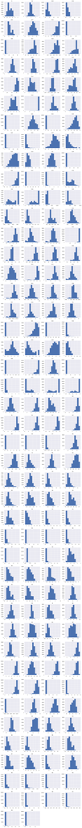

```python
# Histograms for each attribute before pre-processing
X_train_df[columns_to_scale].hist(layout=(dispRow,dispCol))
plt.show()
```

```python
# Apply feature scaling and transformation to the training dataset
scaler = preprocessing.StandardScaler()
scaled_features = scaler.fit_transform(X_train_df[columns_to_scale])
X_train_df.loc[:,tuple(columns_to_scale)] = scaled_features
print(X_train_df.head())
```

```
              f1        f2        f3  ...      f172      f173      f174
180152 -0.899853 -0.740903 -0.127441  ... -0.840260  0.859692  0.704858
63889   1.282236  1.396620  0.246668  ...  1.691337 -1.575456 -1.290729
144685 -1.472854 -1.882312 -1.456723  ...  0.263544 -0.402975  0.704858
253850 -1.266151 -1.245126 -1.468051  ...  1.691337 -1.575456 -1.290729
75400   1.362747  1.448177  0.586183  ... -0.113372  0.138173  0.704858

[5 rows x 174 columns]
```

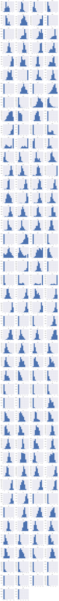

```python
# Histograms for each attribute after pre-processing
X_train_df[columns_to_scale].hist(layout=(dispRow,dispCol))
plt.show()
```

```python
# Apply feature scaling and transformation to the validation dataset
scaled_features = scaler.transform(X_validation_df[columns_to_scale])
X_validation_df.loc[:,tuple(columns_to_scale)] = scaled_features
print(X_validation_df.head())
```

```
              f1        f2        f3  ...      f172      f173      f174
161609 -1.266437 -1.202943 -0.819942  ... -0.113372  0.138173  0.704858
122976  0.259569  0.252743 -0.145810  ...  1.554223 -1.395049 -1.016471
64298   1.257397  1.104545  0.488829  ... -0.113372  0.138173 -1.818663
95086   0.005758  0.141982  0.259832  ... -0.840260  0.859692  0.704858
36211   1.156615  1.157089  2.144278  ...  1.370433 -1.485271 -0.615375

[5 rows x 174 columns]
```

```python
# Apply feature scaling and transformation to the test dataset
scaled_features = scaler.transform(X_test_df[columns_to_scale])
X_test_df.loc[:,tuple(columns_to_scale)] = scaled_features
print(X_test_df.head())
```

```
              f1        f2        f3  ...      f172      f173      f174
75386   1.279381  1.549317  0.329940  ... -0.840260  0.859692  0.704858
315080 -0.346265 -0.564030 -0.285718  ... -0.113372  0.138173  0.704858
163561 -1.399195 -1.203930 -0.845658  ... -0.840260  0.859692  0.704858
312398 -0.421067 -0.280589 -0.640541  ...  0.263544 -0.402975 -0.356355
18169   0.889100  1.030786  1.424102  ... -0.840260  0.859692  0.704858

[5 rows x 174 columns]
```

## 2.f) Display the Final Datasets for Model-Building

```python
# Finalize the training datasets for the modeling activities
X_train = X_train_df.to_numpy()
X_validation = X_validation_df.to_numpy()
X_test = X_test_df.to_numpy()
print("X_train.shape: {} y_train.shape: {}".format(X_train.shape, y_train.shape))
print("X_validation.shape: {} y_validation.shape: {}".format(X_validation.shape, y_validation.shape))
print("X_test.shape: {} y_test.shape: {}".format(X_test.shape, y_test.shape))
```

```
X_train.shape: (195500, 174) y_train.shape: (195500, 7)
X_validation.shape: (65167, 174) y_validation.shape: (65167, 7)
X_test.shape: (65167, 174) y_test.shape: (65167, 7)
```

```python
if (notifyStatus): status_notify("Task 2. Load and Prepare Data completed! "+datetime.now().strftime('%a %B %d, %Y %I:%M:%S %p'))
```

# Task 3. Define and Train Model

```python
if (notifyStatus): status_notify("Task 3. Define and Train Model has begun! "+datetime.now().strftime('%a %B %d, %Y %I:%M:%S %p'))
```

```python
# Define the baseline model for benchmarking
def create_nn_model(layer1_nodes=40, layer2_nodes=32, layer3_nodes=24, layer4_nodes=16, layer5_nodes=8,
                    layer1_dropout=0, layer2_dropout=0, layer3_dropout=0, layer4_dropout=0, layer5_dropout=0,
                    opt_param=default_optimizer, init_param=default_kernel_init):
    nn_model = Sequential()
    nn_model.add(Dense(layer1_nodes, input_shape=(X_train.shape[1],), activation='relu', kernel_initializer=init_param))
    nn_model.add(BatchNormalization())
    nn_model.add(Dropout(layer1_dropout))
    nn_model.add(Dense(layer2_nodes, activation='relu', kernel_initializer=init_param))
    nn_model.add(BatchNormalization())
    nn_model.add(Dropout(layer2_dropout))
    nn_model.add(Dense(layer3_nodes, activation='relu', kernel_initializer=init_param))
    nn_model.add(BatchNormalization())
    nn_model.add(Dropout(layer3_dropout))
    nn_model.add(Dense(layer4_nodes, activation='relu', kernel_initializer=init_param))
    nn_model.add(BatchNormalization())
    nn_model.add(Dropout(layer4_dropout))
    nn_model.add(Dense(layer5_nodes, activation='relu', kernel_initializer=init_param))
    nn_model.add(BatchNormalization())
    nn_model.add(Dropout(layer5_dropout))
    nn_model.add(Dense(num_class, activation='softmax', kernel_initializer=init_param))
    nn_model.compile(loss=default_loss, optimizer=opt_param, metrics=default_metrics)
    return nn_model
```

```python
# Initialize the default model and get a baseline result
startTimeModule = datetime.now()
reset_random(seedNum)
baseline_model = create_nn_model()
baseline_hist = baseline_model.fit(X_train, y_train, epochs=default_epoch, batch_size=default_batch, validation_data=(X_validation, y_validation), verbose=1)
print('Total time for model fitting:', (datetime.now() - startTimeModule))
```

```
Total time for model fitting: 0:08:50.763663
```

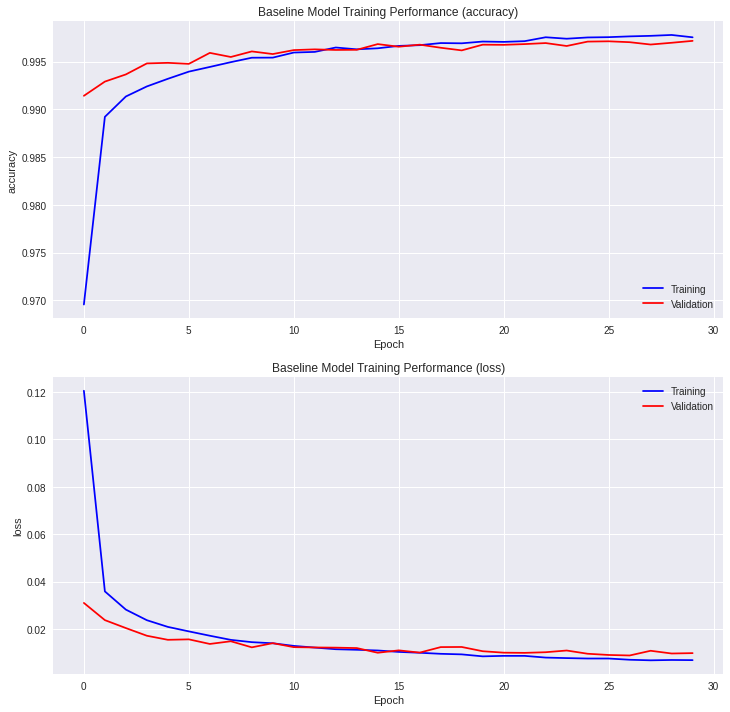

```python
# Summarize model training hisotry
fig, axs = plt.subplots(2, 1, figsize=(12,12))
plt.subplot(211)
plt.plot(baseline_hist.history[train_metric], color='blue', label='train')
plt.plot(baseline_hist.history[validation_metric], color='red', label='validation')
plt.title('Baseline Model Training Performance (%s)' % (train_metric))
plt.ylabel(train_metric)
plt.xlabel('Epoch')
plt.legend(['Training', 'Validation'], loc='lower right')
plt.subplot(212)
plt.plot(baseline_hist.history[train_loss], color='blue', label='train')
plt.plot(baseline_hist.history[validation_loss], color='red', label='validation')
plt.title('Baseline Model Training Performance (%s)' % (train_loss))
plt.ylabel(train_loss)
plt.xlabel('Epoch')
plt.legend(['Training', 'Validation'], loc='upper right')
plt.show()
```

```python
if (notifyStatus): status_notify("Task 3. Define and Train Model completed! "+datetime.now().strftime('%a %B %d, %Y %I:%M:%S %p'))
```

# Task 4. Evaluate and Optimize Model

```python
if (notifyStatus): status_notify("Task 4. Evaluate and Optimize Model has begun! "+datetime.now().strftime('%a %B %d, %Y %I:%M:%S %p'))
```

```python
# Initialize the grid parameters and fit the models
nodes_grid = [(80, 64, 48, 32, 16), (160, 128, 96, 64, 32), (240, 192, 144, 96, 48), (320, 256, 192, 128, 64), (480, 384, 288, 192, 96)]
layer1_dropout, layer2_dropout, layer3_dropout, layer4_dropout, layer5_dropout = (0, 0, 0, 0, 0)

# Build dataframe for reporting model performance summary
nodes_performance = pd.DataFrame(columns=['model_name', 'train_score', 'validation_score', 'variance', 'layer1_nodes', 'layer2_nodes', 'layer3_nodes', 'layer4_nodes',
                                          'layer5_nodes', 'layer1_dropout', 'layer2_dropout', 'layer3_dropout', 'layer4_dropout', 'layer5_dropout'])

serial_number = 0
for param in nodes_grid:
    startTimeModule = datetime.now()
    serial_number = serial_number + 1
    model_name = "Model_" + str(serial_number).zfill(3)
    layer1_nodes, layer2_nodes, layer3_nodes, layer4_nodes, layer5_nodes = param
    reset_random(seedNum)
    grid_search_model = create_nn_model(layer1_nodes, layer2_nodes, layer3_nodes, layer4_nodes, layer5_nodes, layer1_dropout, layer2_dropout,
                                        layer3_dropout, layer4_dropout, layer5_dropout, default_optimizer, default_kernel_init)
    print('Processing model %s with Layer 1: %d, Layer 2: %d, Layer 3: %d, Layer 4: %d, and Layer 5: %d nodes' % (model_name, layer1_nodes, layer2_nodes, layer3_nodes, layer4_nodes, layer5_nodes))
    model_train_hist = grid_search_model.fit(X_train, y_train, epochs=default_epoch, batch_size=default_batch, validation_data=(X_validation, y_validation), verbose=1)
    train_score = model_train_hist.history[train_metric][-1]
    validation_score = model_train_hist.history[validation_metric][-1]
    train_val_variance = abs(train_score - validation_score)
    print('The maximum score for the training dataset: %.2f%%' % (max(model_train_hist.history[train_metric])*100))
    print('The score at the last epoch for the training dataset: %.2f%%' % (train_score*100))
    print('The maximum score for the validation dataset: %.2f%%' % (max(model_train_hist.history[validation_metric])*100))
    print('The score at the last epoch for the validation dataset: %.2f%%' % (validation_score*100))
    print('The training vs. validation variance at the last epoch is: %.4f' % (train_val_variance))
    print('Total time for model fitting:', (datetime.now() - startTimeModule), '\n')
    nodes_performance = nodes_performance.append({'model_name': model_name, 'train_score': train_score, 'validation_score': validation_score, 'variance': train_val_variance,
                                                  'layer1_nodes': layer1_nodes, 'layer2_nodes': layer2_nodes, 'layer3_nodes': layer3_nodes, 'layer4_nodes': layer4_nodes,
                                                  'layer5_nodes': layer5_nodes, 'layer1_dropout': layer1_dropout, 'layer2_dropout': layer2_dropout, 'layer3_dropout': layer3_dropout,
                                                  'layer4_dropout': layer4_dropout, 'layer5_dropout': layer5_dropout}, ignore_index=True)

nodes_performance.set_index('model_name', inplace=True)
```

```
Processing model Model_001 with Layer 1: 80, Layer 2: 64, Layer 3: 48, Layer 4: 32, and Layer 5: 16 nodes
The maximum score for the training dataset: 99.87%
The score at the last epoch for the training dataset: 99.87%
The maximum score for the validation dataset: 99.81%
The score at the last epoch for the validation dataset: 99.81%
The training vs. validation variance at the last epoch is: 0.0007
Total time for model fitting: 0:08:45.441071

Processing model Model_002 with Layer 1: 160, Layer 2: 128, Layer 3: 96, Layer 4: 64, and Layer 5: 32 nodes
The maximum score for the training dataset: 99.90%
The score at the last epoch for the training dataset: 99.89%
The maximum score for the validation dataset: 99.85%
The score at the last epoch for the validation dataset: 99.80%
The training vs. validation variance at the last epoch is: 0.0009
Total time for model fitting: 0:08:53.074815

Processing model Model_003 with Layer 1: 240, Layer 2: 192, Layer 3: 144, Layer 4: 96, and Layer 5: 48 nodes
The maximum score for the training dataset: 99.93%
The score at the last epoch for the training dataset: 99.93%
The maximum score for the validation dataset: 99.84%
The score at the last epoch for the validation dataset: 99.81%
The training vs. validation variance at the last epoch is: 0.0012
Total time for model fitting: 0:09:01.465476

Processing model Model_004 with Layer 1: 320, Layer 2: 256, Layer 3: 192, Layer 4: 128, and Layer 5: 64 nodes
The maximum score for the training dataset: 99.92%
The score at the last epoch for the training dataset: 99.92%
The maximum score for the validation dataset: 99.84%
The score at the last epoch for the validation dataset: 99.79%
The training vs. validation variance at the last epoch is: 0.0014
Total time for model fitting: 0:09:08.354879

Processing model Model_005 with Layer 1: 480, Layer 2: 384, Layer 3: 288, Layer 4: 192, and Layer 5: 96 nodes
The maximum score for the training dataset: 99.93%
The score at the last epoch for the training dataset: 99.93%
The maximum score for the validation dataset: 99.85%
The score at the last epoch for the validation dataset: 99.85%
The training vs. validation variance at the last epoch is: 0.0008
Total time for model fitting: 0:09:13.804759
```

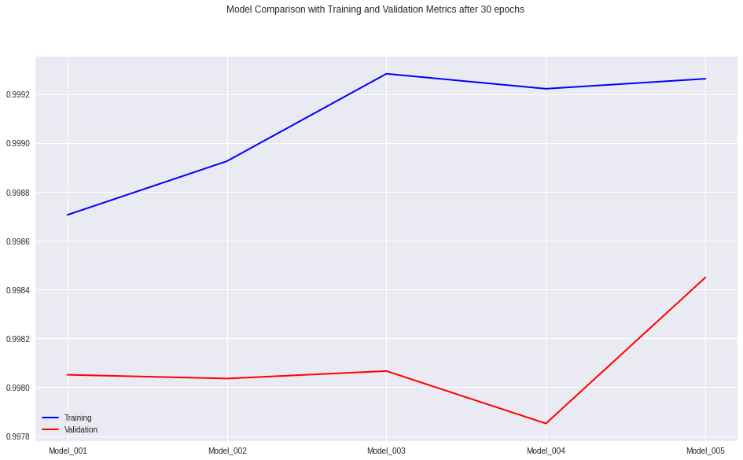

```python
# Spot-checking the models
fig = plt.figure(figsize=(16,9))
title = 'Model Comparison with Training and Validation Metrics after ' + str(default_epoch) + ' epochs'
fig.suptitle(title)
ax1 = fig.add_subplot(111)
ax1.plot(nodes_performance['train_score'], color='b', lw=2.)
ax1.plot(nodes_performance['validation_score'], color='r', lw=2.)
plt.legend(['Training', 'Validation'], loc='lower left')
plt.show()
```

```python
# Initialize the grid parameters for the dropout ratio
startTimeModule = datetime.now()
model_to_use = 'Model_005'
layer1_nodes = nodes_performance.loc[model_to_use]['layer1_nodes']
layer2_nodes = nodes_performance.loc[model_to_use]['layer2_nodes']
layer3_nodes = nodes_performance.loc[model_to_use]['layer3_nodes']
layer4_nodes = nodes_performance.loc[model_to_use]['layer4_nodes']
layer5_nodes = nodes_performance.loc[model_to_use]['layer5_nodes']
layer1_dropout_grid = [0.25, 0.5]
layer2_dropout_grid = [0.25, 0.5]
layer3_dropout_grid = [0.25, 0.5]
layer4_dropout_grid = [0.25, 0.5]
layer5_dropout_grid = [0.5]

# Build dataframe for reporting model performance summary
dropout_performance = pd.DataFrame(columns=['model_name','train_score','validation_score','variance','layer1_nodes','layer2_nodes','layer3_nodes','layer4_nodes',
                                            'layer5_nodes','layer1_dropout','layer2_dropout','layer3_dropout','layer4_dropout','layer5_dropout'])

serial_number = 0
for layer1_dropout in layer1_dropout_grid:
    for layer2_dropout in layer2_dropout_grid:
        for layer3_dropout in layer3_dropout_grid:
            for layer4_dropout in layer4_dropout_grid:
                for layer5_dropout in layer5_dropout_grid:
                    startTimeIteration = datetime.now()
                    serial_number = serial_number + 1
                    model_name = "Model_" + str(serial_number).zfill(3)
                    reset_random(seedNum)
                    grid_search_model = create_nn_model(layer1_nodes, layer2_nodes, layer3_nodes, layer4_nodes, layer5_nodes, layer1_dropout, layer2_dropout,
                                                        layer3_dropout, layer4_dropout, layer5_dropout, default_optimizer, default_kernel_init)
                    print('Processing model %s with Layer 1: %d, Layer 2: %d, Layer 3: %d, Layer 4: %d, and Layer 5: %d nodes and dropout parameters of Layer 1: %.2f, Layer 2: %.2f, Layer 3: %.2f, Layer 4: %.2f, and Layer 5: %.2f' %
                        (model_name, layer1_nodes, layer2_nodes, layer3_nodes, layer4_nodes, layer5_nodes, layer1_dropout, layer2_dropout, layer3_dropout, layer4_dropout, layer5_dropout))
                    model_train_hist = grid_search_model.fit(X_train, y_train, epochs=default_epoch, batch_size=default_batch, validation_data=(X_validation, y_validation), verbose=0)
                    train_score = model_train_hist.history[train_metric][-1]
                    validation_score = model_train_hist.history[validation_metric][-1]
                    train_val_variance = abs(train_score - validation_score)
                    print('The maximum score for the training dataset: %.2f%%' % (max(model_train_hist.history[train_metric])*100))
                    print('The score at the last epoch for the training dataset: %.2f%%' % (train_score*100))
                    print('The maximum score for the validation dataset: %.2f%%' % (max(model_train_hist.history[validation_metric])*100))
                    print('The score at the last epoch for the validation dataset: %.2f%%' % (validation_score*100))
                    print('The training vs. validation variance at the last epoch is: %.4f' % (train_val_variance))
                    print('Total time for model fitting:', (datetime.now() - startTimeIteration), '\n')
                    dropout_performance = dropout_performance.append({'model_name': model_name, 'train_score': train_score, 'validation_score': validation_score, 'variance': train_val_variance,
                                                                    'layer1_nodes': layer1_nodes, 'layer2_nodes': layer2_nodes, 'layer3_nodes': layer3_nodes, 'layer4_nodes': layer4_nodes,
                                                                    'layer5_nodes': layer5_nodes, 'layer1_dropout': layer1_dropout, 'layer2_dropout': layer2_dropout, 'layer3_dropout': layer3_dropout,
                                                                    'layer4_dropout': layer4_dropout, 'layer5_dropout': layer5_dropout}, ignore_index=True)

dropout_performance.set_index('model_name', inplace=True)
print('Total time for performing grid-search of the best dropout parameters:', (datetime.now() - startTimeModule))
```

```
Processing model Model_001 with Layer 1: 480, Layer 2: 384, Layer 3: 288, Layer 4: 192, and Layer 5: 96 nodes and dropout parameters of Layer 1: 0.25, Layer 2: 0.25, Layer 3: 0.25, Layer 4: 0.25, and Layer 5: 0.50
The maximum score for the training dataset: 99.81%
The score at the last epoch for the training dataset: 99.81%
The maximum score for the validation dataset: 99.83%
The score at the last epoch for the validation dataset: 99.83%
The training vs. validation variance at the last epoch is: 0.0002
Total time for model fitting: 0:07:39.302821

Processing model Model_002 with Layer 1: 480, Layer 2: 384, Layer 3: 288, Layer 4: 192, and Layer 5: 96 nodes and dropout parameters of Layer 1: 0.25, Layer 2: 0.25, Layer 3: 0.25, Layer 4: 0.50, and Layer 5: 0.50
The maximum score for the training dataset: 99.81%
The score at the last epoch for the training dataset: 99.81%
The maximum score for the validation dataset: 99.83%
The score at the last epoch for the validation dataset: 99.79%
The training vs. validation variance at the last epoch is: 0.0002
Total time for model fitting: 0:07:31.617278

Processing model Model_003 with Layer 1: 480, Layer 2: 384, Layer 3: 288, Layer 4: 192, and Layer 5: 96 nodes and dropout parameters of Layer 1: 0.25, Layer 2: 0.25, Layer 3: 0.50, Layer 4: 0.25, and Layer 5: 0.50
The maximum score for the training dataset: 99.79%
The score at the last epoch for the training dataset: 99.79%
The maximum score for the validation dataset: 99.83%
The score at the last epoch for the validation dataset: 99.83%
The training vs. validation variance at the last epoch is: 0.0004
Total time for model fitting: 0:07:27.052848

Processing model Model_004 with Layer 1: 480, Layer 2: 384, Layer 3: 288, Layer 4: 192, and Layer 5: 96 nodes and dropout parameters of Layer 1: 0.25, Layer 2: 0.25, Layer 3: 0.50, Layer 4: 0.50, and Layer 5: 0.50
The maximum score for the training dataset: 99.77%
The score at the last epoch for the training dataset: 99.75%
The maximum score for the validation dataset: 99.81%
The score at the last epoch for the validation dataset: 99.81%
The training vs. validation variance at the last epoch is: 0.0006
Total time for model fitting: 0:07:17.339012

Processing model Model_005 with Layer 1: 480, Layer 2: 384, Layer 3: 288, Layer 4: 192, and Layer 5: 96 nodes and dropout parameters of Layer 1: 0.25, Layer 2: 0.50, Layer 3: 0.25, Layer 4: 0.25, and Layer 5: 0.50
The maximum score for the training dataset: 99.76%
The score at the last epoch for the training dataset: 99.76%
The maximum score for the validation dataset: 99.81%
The score at the last epoch for the validation dataset: 99.75%
The training vs. validation variance at the last epoch is: 0.0001
Total time for model fitting: 0:07:13.519236

```

[output cut: 74 more lines]

```
The score at the last epoch for the training dataset: 99.60%
The maximum score for the validation dataset: 99.75%
The score at the last epoch for the validation dataset: 99.75%
The training vs. validation variance at the last epoch is: 0.0015
Total time for model fitting: 0:07:33.258698

Processing model Model_016 with Layer 1: 480, Layer 2: 384, Layer 3: 288, Layer 4: 192, and Layer 5: 96 nodes and dropout parameters of Layer 1: 0.50, Layer 2: 0.50, Layer 3: 0.50, Layer 4: 0.50, and Layer 5: 0.50
The maximum score for the training dataset: 99.57%
The score at the last epoch for the training dataset: 99.57%
The maximum score for the validation dataset: 99.73%
The score at the last epoch for the validation dataset: 99.73%
The training vs. validation variance at the last epoch is: 0.0016
Total time for model fitting: 0:07:32.807771

Total time for performing grid-search of the best dropout parameters: 1:58:36.066604
```

```python
# Display the model performance summary by validation score
dropout_performance.sort_values(by=['validation_score'], ascending=False).head()
```

| model_name | train_score | validation_score | variance | layer1_nodes | layer2_nodes | layer3_nodes | layer4_nodes | layer5_nodes | layer1_dropout | layer2_dropout | layer3_dropout | layer4_dropout | layer5_dropout |
| --- | --- | --- | --- | --- | --- | --- | --- | --- | --- | --- | --- | --- | --- |
| Model_001 | 0.998082 | 0.998312 | 0.000230 | 480 | 384 | 288 | 192 | 96 | 0.25 | 0.25 | 0.25 | 0.25 | 0.5 |
| Model_003 | 0.997857 | 0.998266 | 0.000409 | 480 | 384 | 288 | 192 | 96 | 0.25 | 0.25 | 0.50 | 0.25 | 0.5 |
| Model_004 | 0.997529 | 0.998113 | 0.000583 | 480 | 384 | 288 | 192 | 96 | 0.25 | 0.25 | 0.50 | 0.50 | 0.5 |
| Model_011 | 0.996777 | 0.998082 | 0.001304 | 480 | 384 | 288 | 192 | 96 | 0.50 | 0.25 | 0.50 | 0.25 | 0.5 |
| Model_006 | 0.997381 | 0.997974 | 0.000593 | 480 | 384 | 288 | 192 | 96 | 0.25 | 0.50 | 0.25 | 0.50 | 0.5 |

```python
# Display the model performance summary by variance
dropout_performance.sort_values(by=['variance']).head()
```

| model_name | train_score | validation_score | variance | layer1_nodes | layer2_nodes | layer3_nodes | layer4_nodes | layer5_nodes | layer1_dropout | layer2_dropout | layer3_dropout | layer4_dropout | layer5_dropout |
| --- | --- | --- | --- | --- | --- | --- | --- | --- | --- | --- | --- | --- | --- |
| Model_005 | 0.997627 | 0.997529 | 0.000097 | 480 | 384 | 288 | 192 | 96 | 0.25 | 0.50 | 0.25 | 0.25 | 0.5 |
| Model_007 | 0.997350 | 0.997453 | 0.000102 | 480 | 384 | 288 | 192 | 96 | 0.25 | 0.50 | 0.50 | 0.25 | 0.5 |
| Model_002 | 0.998056 | 0.997882 | 0.000174 | 480 | 384 | 288 | 192 | 96 | 0.25 | 0.25 | 0.25 | 0.50 | 0.5 |
| Model_001 | 0.998082 | 0.998312 | 0.000230 | 480 | 384 | 288 | 192 | 96 | 0.25 | 0.25 | 0.25 | 0.25 | 0.5 |
| Model_003 | 0.997857 | 0.998266 | 0.000409 | 480 | 384 | 288 | 192 | 96 | 0.25 | 0.25 | 0.50 | 0.25 | 0.5 |

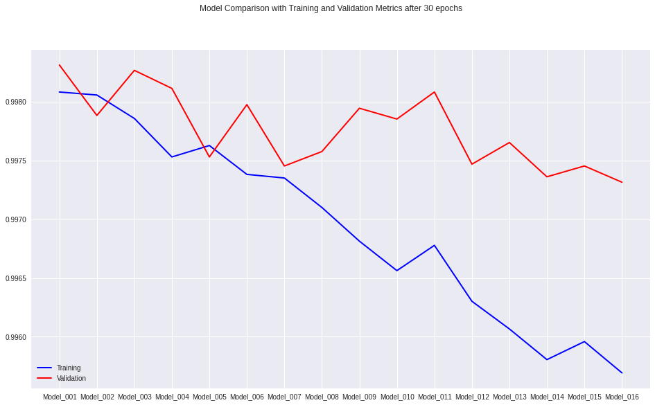

```python
# Spot-checking the models
fig = plt.figure(figsize=(16,9))
title = 'Model Comparison with Training and Validation Metrics after ' + str(default_epoch) + ' epochs'
fig.suptitle(title)
ax1 = fig.add_subplot(111)
ax1.plot(dropout_performance['train_score'], color='b', lw=2.)
ax1.plot(dropout_performance['validation_score'], color='r', lw=2.)
plt.legend(['Training', 'Validation'], loc='lower left')
plt.show()
```

```python
# Initialize the grid parameters for the optimizer, kernel, and batch size
startTimeModule = datetime.now()
model_to_use = 'Model_001'
layer1_nodes = dropout_performance.loc[model_to_use]['layer1_nodes']
layer2_nodes = dropout_performance.loc[model_to_use]['layer2_nodes']
layer3_nodes = dropout_performance.loc[model_to_use]['layer3_nodes']
layer4_nodes = dropout_performance.loc[model_to_use]['layer4_nodes']
layer5_nodes = dropout_performance.loc[model_to_use]['layer5_nodes']
layer1_dropout = dropout_performance.loc[model_to_use]['layer1_dropout']
layer2_dropout = dropout_performance.loc[model_to_use]['layer2_dropout']
layer3_dropout = dropout_performance.loc[model_to_use]['layer3_dropout']
layer4_dropout = dropout_performance.loc[model_to_use]['layer4_dropout']
layer5_dropout = dropout_performance.loc[model_to_use]['layer5_dropout']

# Set up grid search using different epochs, batch sizes, and optimizers
optz_1 = tf.keras.optimizers.Adam(learning_rate=0.001)
optz_2 = tf.keras.optimizers.RMSprop(learning_rate=0.001)
optz_3 = tf.keras.optimizers.SGD(learning_rate=0.01)
optimizer_grid = [optz_1, optz_2, optz_3]
print('Optimizer candidate #1 has the object ID of', optz_1)
print('Optimizer candidate #2 has the object ID of', optz_2)
print('Optimizer candidate #3 has the object ID of', optz_3)

init_1 = tf.keras.initializers.he_uniform(seed=seedNum)
init_2 = tf.keras.initializers.Orthogonal(seed=seedNum)
init_3 = tf.keras.initializers.RandomUniform(seed=seedNum)
init_grid = [init_1, init_2, init_3]
print('Initializer candidate #1 has the object ID of', init_1)
print('Initializer candidate #2 has the object ID of', init_2)
print('Initializer candidate #3 has the object ID of', init_3)

epoch_grid = [default_epoch]
batch_grid = [int(default_batch/2), default_batch]

grid_iteration = 1
best_score = 0
best_iteration = 0
best_optimizer = default_optimizer
best_kernel_init = default_kernel_init
best_epoch = default_epoch
best_batch = default_batch

for optimizer in optimizer_grid:
    for kernel_init in init_grid:
        for epoch_num in epoch_grid:
            for batch_num in batch_grid:
                startTimeIteration = datetime.now()
                print('\nForming the grid-search model #%d using: optimizer=%s, kernel=%s, epochs=%d, batch_size=%d'
                      % (grid_iteration, optimizer, kernel_init, epoch_num, batch_num))
                reset_random(seedNum)
                grid_model = create_nn_model(layer1_nodes, layer2_nodes, layer3_nodes, layer4_nodes, layer5_nodes, layer1_dropout, layer2_dropout,
                                             layer3_dropout, layer4_dropout, layer5_dropout, optimizer, kernel_init)
                grid_hist = grid_model.fit(X_train, y_train, epochs=epoch_num, batch_size=batch_num, validation_data=(X_validation, y_validation), verbose=0)
                train_score = grid_hist.history[train_metric][-1]
                validation_score = grid_hist.history[validation_metric][-1]
                train_val_variance = abs(train_score - validation_score)
                print('The maximum score for the training dataset: %.2f%%' % (max(grid_hist.history[train_metric])*100))
                print('The score at the last epoch for the training dataset: %.2f%%' % (train_score*100))
                print('The maximum score for the validation dataset: %.2f%%' % (max(grid_hist.history[validation_metric])*100))
                print('The score at the last epoch for the validation dataset: %.2f%%' % (validation_score*100))
                print('The training vs. validation variance at the last epoch is: %.4f' % (train_val_variance))
                print('Total time for model fitting:', (datetime.now() - startTimeIteration), '\n')
                if(grid_hist.history['val_accuracy'][-1] > best_score):
                    best_score = grid_hist.history['val_accuracy'][-1]
                    best_iteration = grid_iteration
                    best_optimizer = optimizer
                    best_kernel_init = kernel_init
                    best_epoch = epoch_num
                    best_batch = batch_num
                grid_iteration = grid_iteration + 1

# summarize results
print("\nBest score (highest validation accuracy) found via grid search: accuracy=%f from model iteration #%d"
      % (best_score, best_iteration))
print('The best modeling parameters are: optimizer=%s, kernel=%s, epochs=%d, batch_size=%d'
      % (best_optimizer, best_kernel_init, best_epoch, best_batch))
print('Total time for performing grid-search of the best parameters:', (datetime.now() - startTimeModule))
```

```
Optimizer candidate #1 has the object ID of <tensorflow.python.keras.optimizer_v2.adam.Adam object at 0x7f12b5b66208>
Optimizer candidate #2 has the object ID of <tensorflow.python.keras.optimizer_v2.rmsprop.RMSprop object at 0x7f12b14ada20>
Optimizer candidate #3 has the object ID of <tensorflow.python.keras.optimizer_v2.gradient_descent.SGD object at 0x7f12b14ad668>
Initializer candidate #1 has the object ID of <tensorflow.python.ops.init_ops_v2.VarianceScaling object at 0x7f12b14add30>
Initializer candidate #2 has the object ID of <tensorflow.python.ops.init_ops_v2.Orthogonal object at 0x7f12b14ad748>
Initializer candidate #3 has the object ID of <tensorflow.python.ops.init_ops_v2.RandomUniform object at 0x7f12b14ad588>

Forming the grid-search model #1 using: optimizer=<tensorflow.python.keras.optimizer_v2.adam.Adam object at 0x7f12b5b66208>, kernel=<tensorflow.python.ops.init_ops_v2.VarianceScaling object at 0x7f12b14add30>, epochs=30, batch_size=32
The maximum score for the training dataset: 99.75%
The score at the last epoch for the training dataset: 99.74%
The maximum score for the validation dataset: 99.81%
The score at the last epoch for the validation dataset: 99.81%
The training vs. validation variance at the last epoch is: 0.0008
Total time for model fitting: 0:14:41.225617


Forming the grid-search model #2 using: optimizer=<tensorflow.python.keras.optimizer_v2.adam.Adam object at 0x7f12b5b66208>, kernel=<tensorflow.python.ops.init_ops_v2.VarianceScaling object at 0x7f12b14add30>, epochs=30, batch_size=64
The maximum score for the training dataset: 99.81%
The score at the last epoch for the training dataset: 99.81%
The maximum score for the validation dataset: 99.83%
The score at the last epoch for the validation dataset: 99.80%
The training vs. validation variance at the last epoch is: 0.0000
Total time for model fitting: 0:07:37.072442


Forming the grid-search model #3 using: optimizer=<tensorflow.python.keras.optimizer_v2.adam.Adam object at 0x7f12b5b66208>, kernel=<tensorflow.python.ops.init_ops_v2.Orthogonal object at 0x7f12b14ad748>, epochs=30, batch_size=32
The maximum score for the training dataset: 99.75%
The score at the last epoch for the training dataset: 99.75%
The maximum score for the validation dataset: 99.81%
The score at the last epoch for the validation dataset: 99.78%
The training vs. validation variance at the last epoch is: 0.0003
Total time for model fitting: 0:14:32.924856


Forming the grid-search model #4 using: optimizer=<tensorflow.python.keras.optimizer_v2.adam.Adam object at 0x7f12b5b66208>, kernel=<tensorflow.python.ops.init_ops_v2.Orthogonal object at 0x7f12b14ad748>, epochs=30, batch_size=64
The maximum score for the training dataset: 99.80%
The score at the last epoch for the training dataset: 99.80%
The maximum score for the validation dataset: 99.82%
The score at the last epoch for the validation dataset: 99.82%
The training vs. validation variance at the last epoch is: 0.0002
```

[output cut: 117 more lines]

```
Total time for model fitting: 0:13:46.792040


Forming the grid-search model #18 using: optimizer=<tensorflow.python.keras.optimizer_v2.gradient_descent.SGD object at 0x7f12b14ad668>, kernel=<tensorflow.python.ops.init_ops_v2.RandomUniform object at 0x7f12b14ad588>, epochs=30, batch_size=64
The maximum score for the training dataset: 99.67%
The score at the last epoch for the training dataset: 99.66%
The maximum score for the validation dataset: 99.81%
The score at the last epoch for the validation dataset: 99.81%
The training vs. validation variance at the last epoch is: 0.0015
Total time for model fitting: 0:07:08.980678


Best score (highest validation accuracy) found via grid search: accuracy=0.998220 from model iteration #4
The best modeling parameters are: optimizer=<tensorflow.python.keras.optimizer_v2.adam.Adam object at 0x7f12b5b66208>, kernel=<tensorflow.python.ops.init_ops_v2.Orthogonal object at 0x7f12b14ad748>, epochs=30, batch_size=64
Total time for performing grid-search of the best parameters: 3:28:12.189798
```

```python
if (notifyStatus): status_notify("Task 4. Evaluate and Optimize Model completed! "+datetime.now().strftime('%a %B %d, %Y %I:%M:%S %p'))
```

# Task 5. Finalize Model and Make Predictions

```python
if (notifyStatus): status_notify("Task 5. Finalize Model and Make Predictions has begun! "+datetime.now().strftime('%a %B %d, %Y %I:%M:%S %p'))
```

```python
# Combining the training and validation datasets to form the dataset that will be used for training the final model
X_train_val = np.vstack((X_train, X_validation))
y_train_val = np.concatenate((y_train, y_validation))
print("X_train_val.shape: {} y_train_val.shape: {}".format(X_train_val.shape, y_train_val.shape))
```

```
X_train_val.shape: (260667, 174) y_train_val.shape: (260667, 7)
```

```python
final_optimizer = best_optimizer
final_kernel_init = best_kernel_init
final_epoch = best_epoch
final_batch = best_batch
print('Processing final model with Layer 1: %d, Layer 2: %d, Layer 3: %d, and Layer 4: %d nodes and with dropout parameters of Layer 1: %.2f, Layer 2: %.2f, Layer 3: %.2f, and Layer 4: %.2f.' %
      (layer1_nodes, layer2_nodes, layer3_nodes, layer4_nodes, layer1_dropout, layer2_dropout, layer3_dropout, layer4_dropout))
print('The final modeling parameters are: optimizer=%s, kernel=%s, epochs=%d, batch_size=%d' % (best_optimizer, best_kernel_init, best_epoch, best_batch))
final_model = create_nn_model(layer1_nodes, layer2_nodes, layer3_nodes, layer4_nodes, layer5_nodes, layer1_dropout, layer2_dropout, layer3_dropout, layer4_dropout, layer5_dropout, final_optimizer, final_kernel_init)
final_hist = final_model.fit(X_train_val, y_train_val, epochs=final_epoch, batch_size=final_batch, verbose=1)
print(final_model.summary())
```

```
Processing final model with Layer 1: 480, Layer 2: 384, Layer 3: 288, and Layer 4: 192 nodes and with dropout parameters of Layer 1: 0.25, Layer 2: 0.25, Layer 3: 0.25, and Layer 4: 0.25.
The final modeling parameters are: optimizer=<tensorflow.python.keras.optimizer_v2.adam.Adam object at 0x7f12b5b66208>, kernel=<tensorflow.python.ops.init_ops_v2.Orthogonal object at 0x7f12b14ad748>, epochs=30, batch_size=64
Model: "sequential_54"
_________________________________________________________________
Layer (type)                 Output Shape              Param #
=================================================================
dense_324 (Dense)            (None, 480)               84000
_________________________________________________________________
batch_normalization_270 (Bat (None, 480)               1920
_________________________________________________________________
dropout_270 (Dropout)        (None, 480)               0
_________________________________________________________________
dense_325 (Dense)            (None, 384)               184704
_________________________________________________________________
batch_normalization_271 (Bat (None, 384)               1536
_________________________________________________________________
dropout_271 (Dropout)        (None, 384)               0
_________________________________________________________________
dense_326 (Dense)            (None, 288)               110880
_________________________________________________________________
batch_normalization_272 (Bat (None, 288)               1152
_________________________________________________________________
dropout_272 (Dropout)        (None, 288)               0
_________________________________________________________________
dense_327 (Dense)            (None, 192)               55488
_________________________________________________________________
batch_normalization_273 (Bat (None, 192)               768
_________________________________________________________________
dropout_273 (Dropout)        (None, 192)               0
_________________________________________________________________
dense_328 (Dense)            (None, 96)                18528
_________________________________________________________________
batch_normalization_274 (Bat (None, 96)                384
_________________________________________________________________
dropout_274 (Dropout)        (None, 96)                0
_________________________________________________________________
dense_329 (Dense)            (None, 7)                 679
=================================================================
Total params: 460,039
Trainable params: 457,159
Non-trainable params: 2,880
_________________________________________________________________
None
```

```python
# Display the configuration of the final model
print(final_model.get_config())
```

```
{'name': 'sequential_54', 'layers': [{'class_name': 'Dense', 'config': {'name': 'dense_324', 'trainable': True, 'batch_input_shape': (None, 174), 'dtype': 'float32', 'units': 480, 'activation': 'relu', 'use_bias': True, 'kernel_initializer': {'class_name': 'Orthogonal', 'config': {'gain': 1.0, 'seed…
```

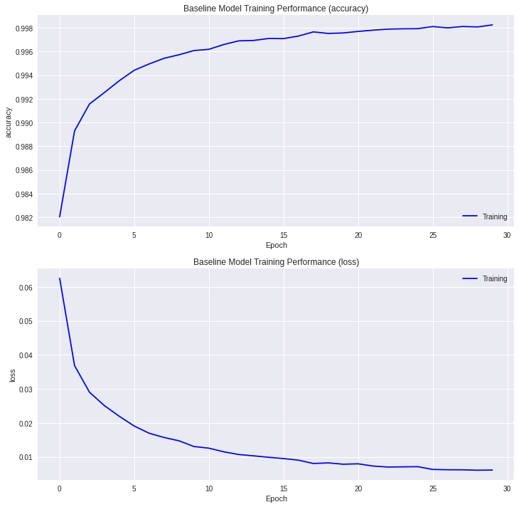

```python
# Summarize model training hisotry
fig, axs = plt.subplots(2, 1, figsize=(12,12))
plt.subplot(211)
plt.plot(final_hist.history[train_metric], color='blue', label='train')
plt.title('Baseline Model Training Performance (%s)' % (train_metric))
plt.ylabel(train_metric)
plt.xlabel('Epoch')
plt.legend(['Training'], loc='lower right')
plt.subplot(212)
plt.plot(final_hist.history[train_loss], color='blue', label='train')
plt.title('Baseline Model Training Performance (%s)' % (train_loss))
plt.ylabel(train_loss)
plt.xlabel('Epoch')
plt.legend(['Training'], loc='upper right')
plt.show()
```

```python
# Evaluate the Keras model on previously unseen data
scores = final_model.evaluate(X_test, y_test)
print("\n%s: %f%%" % (final_model.metrics_names[1], scores[1]*100))
print("\n%s: %f" % (final_model.metrics_names[0], scores[0]))
```

```
accuracy: 99.835807%

loss: 0.016536
```

```python
# Make class predictions with the model
predictions = np.argmax(final_model.predict(X_test), axis=-1)

# Summarize the first 20 cases
for i in range(20):
	print('Data item #%d predicted to be %s (expected %s)' % (i, encoder.inverse_transform([predictions[i]])[0], encoder.inverse_transform([np.argmax(y_test[i])])[0]))
```

```
Data item #0 predicted to be 3 (expected 3)
Data item #1 predicted to be 6 (expected 6)
Data item #2 predicted to be 4 (expected 4)
Data item #3 predicted to be 6 (expected 6)
Data item #4 predicted to be 1 (expected 1)
Data item #5 predicted to be 3 (expected 3)
Data item #6 predicted to be 1 (expected 1)
Data item #7 predicted to be 1 (expected 1)
Data item #8 predicted to be 6 (expected 6)
Data item #9 predicted to be 3 (expected 3)
Data item #10 predicted to be 5 (expected 5)
Data item #11 predicted to be 4 (expected 4)
Data item #12 predicted to be 1 (expected 1)
Data item #13 predicted to be 1 (expected 1)
Data item #14 predicted to be 3 (expected 3)
Data item #15 predicted to be 6 (expected 6)
Data item #16 predicted to be 5 (expected 5)
Data item #17 predicted to be 5 (expected 5)
Data item #18 predicted to be 4 (expected 4)
Data item #19 predicted to be 1 (expected 1)
```

```python
if (notifyStatus): status_notify("Task 5. Finalize Model and Make Predictions completed! "+datetime.now().strftime('%a %B %d, %Y %I:%M:%S %p'))
```

```python
print ('Total time for the script:',(datetime.now() - startTimeScript))
```

```
Total time for the script: 9:32:00.536417
```